# FRF reconstruction

## 1 Basic principle

From the identified modal parameters (poles and residues), it is possible to reconstruct the frequency response functions (FRFs) of the system under study using the `frf_reconstruction` function. This function implements the following relation for a number $M$ of identified modes:

$$H_{pq}(\omega) = \sum_{i = 1}^{M} \left[\frac{{}_i R_{pq}}{(j\omega - \lambda_i)} + \frac{{}_i R_{pq}^\ast}{(j\omega - \lambda_i^\ast)}\right],$$
where:

- $\lambda_i = -\xi_i + j\,\Omega_i$ is the pole related to the mode $i$, with:
  - $\Omega_i = \omega_i\sqrt{1 - \xi_i^2}$ is the damped natural frequency of the mode $i$, with $\omega_i = \vert \lambda_i\vert$.
  - $\xi_i = -\frac{\text{Re}(\lambda_i)}{\omega_i}$ the modal damping factor of the mode $i$
- ${}_i R_{pq} = c_i\, \phi_i(x_p)\, \phi_i(x_q)$ is the residue of the mode $i$, with:
  - $\phi_i(x_p)$ the mode shape of the mode $i$ at point $x_p$
  - $c_i = \frac{1}{2jM_i\Omega_i}$ the normalization constant of the mode shape of the mode $i$

In practice, however, the reconstructed FRF may not perfectly match the experimental FRF due to the unmodeled contribution of the modes outside the frequency range of interest. To account for this, it is common to include lower and upper residuals in the FRF reconstruction. This means that the admittance matrix can be expressed as:
$$H_{pq}(\omega) = \sum_{i = 1}^{M} \left[\frac{{}_i R_{pq}}{(j\omega - \lambda_i)} + \frac{{}_i R_{pq}^\ast}{(j\omega - \lambda_i^\ast)}\right] - \frac{L_{pq}}{\omega^2} + U_{pq},$$
where $L_{pq}$ and $U_{pq}$ are the lower and upper residuals, respectively. These residuals can be computed using the `compute_residuals` function.

**Note**

Theoretically, the residuals can be computed in conjunction with the estimation of the residues using a least-squares approach. However, we observed that this often leads to inaccurate estimates of the residuals. Therefore, in `StructuralVibration.jl`, the computation of the residuals is performed separately after estimating the residues and poles.

Finally, when only real mode shapes are available, it is possible to compute the residues from the modal parameters using the `mode2residues` function. This function implements the following relation:
$${}_i R_{pq} = c_i\, \phi_i(x_p)\, \phi_i(x_q),$$
where $\phi_i(x_p)$ is the mode shape of the mode $i$ at point $x_p$ and $c_i = \frac{1}{2jM_i\Omega_i}$ is the normalization constant of the mode shape of the mode $i$. Here, $M_i = 1$, since the mode shapes are mass-normalized. during the extraction process.

## 2 API

**frf_reconstruction**

```
frf_reconstruction(res, poles, freq; lr, ur, type)
```

Reconstruct a frequency response function (FRF) from its residues and poles.

**Inputs**

- `res::Array{Complex, 3}`: Residues corresponding to each pole

- `poles::Vector{Complex}`: Poles extracted from the FRF

- `freq::Vector{Float64}`: Frequency vector

- `lr::Matrix{Complex, 2}`: Lower residuals (default: zeros)

- `ur::Matrix{Complex, 2}`: Upper residuals (default: zeros)

- `type::Symbol`: Type of FRF to reconstruct

  - `:dis`: displacement (default)

  - `:vel`: velocity

  - `:acc`: acceleration

**Output**

- `H_rec::Array{Complex, 3}`: Reconstructed FRF

**compute_residuals**

```
compute_residuals(prob, res, poles)
```

Compute lower and upper residuals of a frequency response function (FRF) given its residues and poles.

**Inputs**

- `prob::Union{EMASdofProblem, EMAMdofProblem}`: Structure containing FRF data and frequency vector

- `res::Array{Complex, 3}`: Residues corresponding to each pole

- `poles::Vector{T}`: Poles extracted from the FRF

**Outputs**

- `lr::Matrix{Complex, 2}`: Lower residuals

- `ur::Matrix{Complex, 2}`: Upper residuals

**mode2residues**

```
mode2residues(ms, poles, idx_m, idx_e)
```

Compute the mode residues from mode shapes and poles.

**Inputs**

- `ms::Matrix{Complex, 2}`: Mode shapes matrix

- `poles::Vector{Complex}`: Poles extracted from the FRF

- `idx_m::Vector{Int}`: Indices of measurement locations

- `idx_e::Vector{Int}`: Indices of excitation locations

**Output**

- `res::Array{Complex, 3}`: Residues corresponding to each pole

**Note** The mode shapes are supposed to be real and mass-normalized.

## 3 Example

### 3.1 Data preparation and FRF calculation

```julia
# Structure parameters of the beam
L = 1.        # Length
b = 0.03      # Width
h = 0.01      # Thickness
S = b*h       # Cross-section area
Iz = b*h^3/12 # Moment of inertia

# Material parameters
E = 2.1e11  # Young's modulus
ρ = 7850.   # Density
ξ = 0.01    # Damping ratio

# Mesh
xexc = 0:0.05:L
xm = xexc[2]

# Mode calculation - Simply supported boundary conditions
beam = Beam(L, S, Iz, E, ρ)
fmax = 500.

ωn, kn = modefreq(beam, 2fmax)
ϕexc = modeshape(beam, kn, xexc)
ϕm = modeshape(beam, kn, xm)

# FRF calculation
freq = 1.:0.1:fmax
prob = ModalFRFProblem(ωn, ξ, freq, ϕm, ϕexc)
H = solve(prob; ismat = true).u
```

### 3.2 Sdof method

```julia
# Problem definition
prob_sdof = EMASdofProblem(H, freq)

# Poles extraction using the Peak Picking method
poles_pp = poles_extraction(prob_sdof, PeakPicking())

# Mode shape extraction
dpi = [1, 2]
ϕr = modeshape_extraction(prob_sdof, poles_pp, dpi)

# Computation of the mode residues
res_pp = mode2residues(ϕr, poles_pp, [2], 1:21)

# FRF reconstruction - without residuals
H_sdof = frf_reconstruction(res_pp, poles_pp, freq)

# FRF reconstruction - with residuals
lr, ur = compute_residuals(prob_sdof, res_pp, poles_pp)
H_sdof2 = frf_reconstruction(res_pp, poles_pp, freq, lr = lr, ur = ur)
```

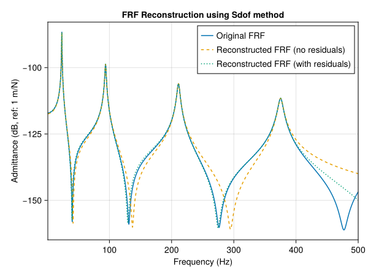

### 3.3 Mdof method

```julia
# Problem definition
prob_mdof = EMAMdofProblem(H, freq)

# Poles extraction using the Least-Squares Complex Frequency-domain method
poles_lscf = poles_extraction(prob_mdof, 20, LSCF())

# Residues extraction
res_lscf = mode_residues(prob_mdof, poles_lscf)

# FRF reconstruction - without residuals
H_mdof = frf_reconstruction(res_lscf, poles_lscf, freq)

# FRF reconstruction - with residuals
lr, ur = compute_residuals(prob_mdof, res_lscf, poles_lscf)
H_mdof2 = frf_reconstruction(res_lscf, poles_lscf, freq, lr = lr, ur = ur)
```

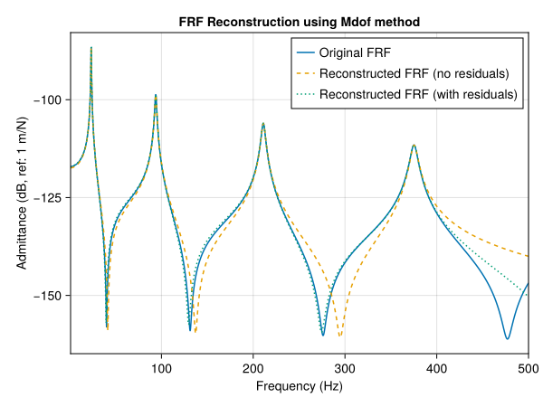